# A3: Incarceration

Altti K

### Introduction

The jail and prison population in the United States is a big issue that shows many of our societal and systemic problems. The U.S. has one of the highest incarceration rates in the world, along with a significant racial and ethnic disparities as well. This is why I decided to look at the overall changes in jail populations as well as rates for specific minorities such as Black and Latinx. Understanding trends and rates of jail and prison populations across different states and counties is very important for working on these issues. Data on jail and prison populations can bring to light patterns and trends that can be a big help to inform policy decisions, areas that need reform, and creating a more equitable justice system.

### Summary Information

For this assignment I have chosen to analyze the total jail population as well as the Black and White jail population rates.

I found the current averages across all counties for White and Black jail populations, which showed how the Black population was over 5 times people higher than the average White population which shows how the disparity of Black being incarcerated much more shows up across the country.

The county that had the most turned out to be King county with over 25,000 people in the jail system, and even if this data point is from 2018, it shows that something has to change if other larger counties are doing better.

Next there ended up being 5 counties total that had 0 total jail population but that number shouldn’t be that low, there should be a couple more with 0 if you consider how many counties there are.

Finally in the last year the average change was positive, meaning since 2017, jail populations across the country have gone up by 7.

```
## [1] "Average current Black jail rate: 2519.28705266712"
```

```
## [1] "Average current White jail rate: 498.129169480081"
```

```
## [1] "Current highest jail pop: King County with a jail pop of 26654.55"
```

```
## [1] "5 places have 0 jail pop: Caldwell County"
## [2] "5 places have 0 jail pop: Lyon County"
## [3] "5 places have 0 jail pop: Big Stone County"
## [4] "5 places have 0 jail pop: Stevens County"
## [5] "5 places have 0 jail pop: Traverse County"
```

```
## [1] "Average change since 2017: 7.1196588990206"
```

### The Dataset

Who collected the data?  
Vera Institute

How was the data collected or generated?  
Data was collected using the bureau of Justice Statistics (BJS) as well as the Census of Jails (COJ)

Why was the data collected?  
To allow research on the county level instead of the state level for more robust and grounded studies

How many observations (rows) are in your data?  
There are 91,031 observations/rows

How many features (columns) are in the data?  
There are 23 features/columns

What, if any, ethical questions or questions of power do you need to consider when working with this data?  
There are some important ethical questions/questions of power that I need to consider such as how the use of this data affects the represented incarcerated community and how people in higher power will view the community as a result.

What are possible limitations or problems with this data? (at least 200 words)

Looking through the data set, there seems to be a lot of N/A data points. This means that either a lot of data was not collected some years or was not accessible. This poses a problem when analyzing the data set, with how many empty data points there are for some variables for certain years and places, some analyses can very possibly become inaccurate or wrong. This also means to be more accurate, variables will be much more limited in which ones are the best to use. Also in this data set, jail variables are much more filled in compared to prison variables which means using prison number for analysis will be much more inaccurate compared to jail variables. Looking at 2018, every single spot for prison variables is labeled N/A which makes more recent analyses impossible.

### Trends Over Time Chart

From this first trends over time chart, it shows how Black and Latinx jail populations have been much much higher than White jail populations. This graph does show signs of Black incarceration rates dropping a lot since late 1990s, but, looking at the more recent years, the decrease is slowing down. Latinx population is hovering between the White and Black population lines. But if you compare this graph to the actual populations in the US, the populations rates should be almost flipped.

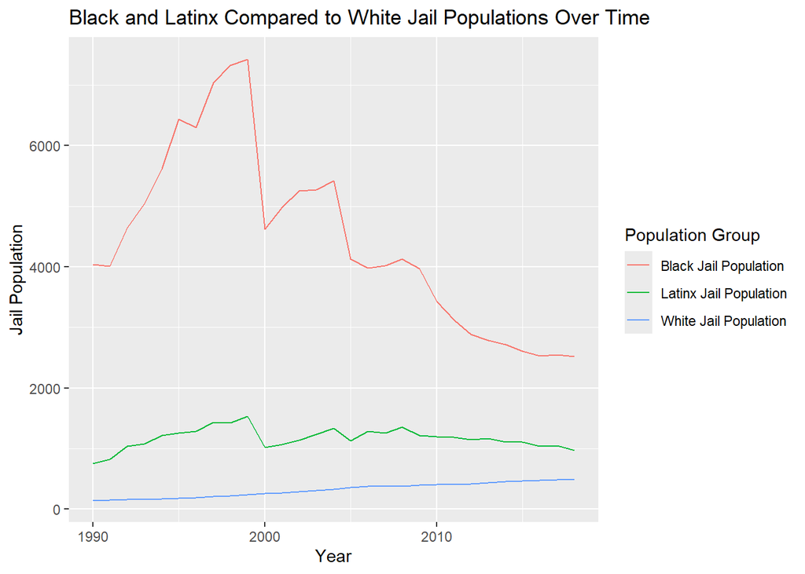

### Variable Comparison Chart

From this chart that compares each counties White jail population with Black and Latinx jail populations, we can see how most counties are bunched up to the left which means that there are much more Black and Latinx people in the jail system in those counties than White. There are only a handful of outliers as well which shows the extent of how common the disparities are.

Note: counties with N/A values were not graphed

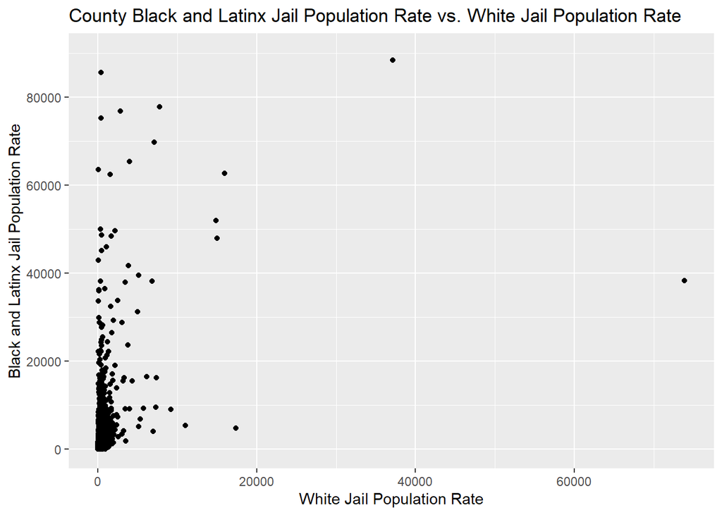

### Map

From this map, it shows how in the last decade while some states have kept jail populations the same or even lowered them, there are still many states that have very high population rate changes. For example Kentucky has the highest with over 30,000 more people in jail across 10 years than before. On the other hand a lot of states also are in the negatives such as Washington or Florida which have a hint of green instead of red. It shows how varied the country is in dealing with incarceration effectively.

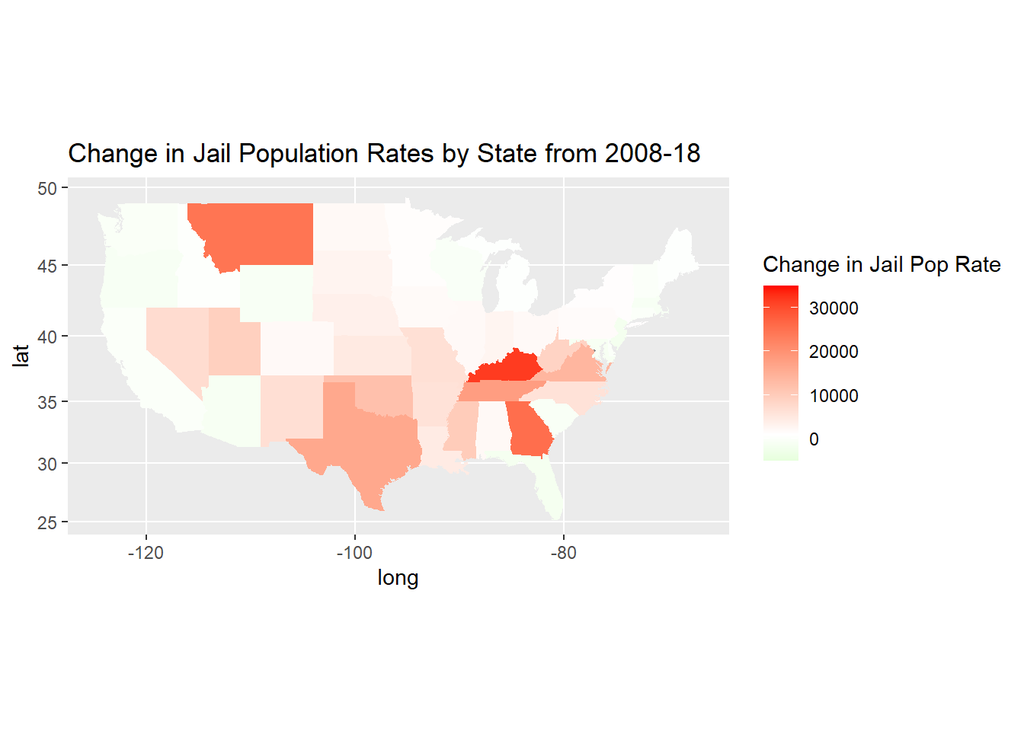